# Project: Correlation between GdP and democracy with expend in military and health, suicide level and sugar consuption between 1995 to 2010 with focus on outler countries

- Introduction
- Data Wrangling
- Exploratory Data Analysis
- Conclusions

## Introduction

> My investigation will analyse the evolution expend in military and health, suicide level and sugar consuption from 1995 to 2010 in relation with the GdP increase and the democracy score evolution. I will try to answer two questions:
> 1. Have GbP along the period influence the expend in military and health, suicide level and sugar consuption? General world view and focus on countries with higher positive or negative correlation (over 0.8 and below -0.8)
> 2. Have democracy variation influence the expend in military and health, suicide level and sugar consuption? General world view and focus on countries with higher positive or negative correlation (over 0.8 and below -0.8)

> I will use gapminder datasets
> 1. GdP: total_gdp_ppp_inflation_adjusted PPD GDP is gross domestic product converted to international dollars using purchaign power parity rates. A PPP dolar has the same purchasing power over GDO as the U.S. dollar has in the United States. Data are in constant 2005 internation dolars
> 2. Health: health_spending_per_person_international_dollar The average health expenditure per person, expressed ininternationl dollars using PPT (Purchaing Power Parity)
> 3. Democracy It is a summary measure of a country democracy and free nature (-10 lowest, 10 highest).
> 4. Military expenditure Military expenditures data from SIPRI are derived from the NATO definition, which includes all current and capital expenditures on the armed forces. This definition is not fully applied for all the countries as not all information needed avalaible
> 5. Sugar per person (g per day) The quantity of food cmpsuption of sugar and sweeteners (grams per person per day). 2004 rough extrapolation by Gapminder
> 6. Suicide, total deaths Total number of estimated deaths from self-inflicted injury

```python
import pandas as pd
import numpy as np
from matplotlib import pyplot
import matplotlib.pyplot as plt
import seaborn as sns
sns.set(color_codes=True)
%matplotlib inline
```

## Data Wrangling

### General Properties

```python
# Import files from my desk
# Path to my desk
path = "C:/Users/sanchez_sanc/Desktop/data_analyst/Curso/2_Data_Analysis/Projecto/data/"

# Import GdP, Democracy score, Health and military expend, sugar per person and suicide
gdp0 = pd.read_csv(path + "total_gdp_ppp_inflation_adjusted.csv", index_col="country")
democracy0= pd.read_csv(path + "democracy_score_use_as_color.csv", index_col="country")

health0 = pd.read_csv(path + "total_health_spending_per_person_international_dollar.csv", index_col="country")
military0=pd.read_csv(path + "ms_mil_xpnd_cd.csv", index_col="country")

sugar0= pd.read_csv(path + "sugar_per_person_g_per_day.csv", index_col="country")
suicide0= pd.read_csv(path + "suicide_total_deaths.csv", index_col="country")
```

```python
# I select the years I will use for the analysis (1995 - 2010) in all the dataframes
gdp1 = gdp0.loc[:, "1995" : "2010"]
gdp1.head(3)
```

| country | 1995 | 1996 | 1997 | 1998 | 1999 | 2000 | 2001 | 2002 | 2003 | 2004 | 2005 | 2006 | 2007 | 2008 | 2009 | 2010 |
| --- | --- | --- | --- | --- | --- | --- | --- | --- | --- | --- | --- | --- | --- | --- | --- | --- |
| Afghanistan | 1.600000e+10 | 1.720000e+10 | 1.820000e+10 | 1.910000e+10 | 2.000000e+10 | 2.040000e+10 | 1.890000e+10 | 2.410000e+10 | 2.710000e+10 | 2.890000e+10 | 3.240000e+10 | 3.390000e+10 | 3.850000e+10 | 3.950000e+10 | 4.750000e+10 | 5.130000e+10 |
| Albania | 1.360000e+10 | 1.470000e+10 | 1.300000e+10 | 1.460000e+10 | 1.590000e+10 | 1.700000e+10 | 1.820000e+10 | 1.880000e+10 | 1.990000e+10 | 2.110000e+10 | 2.230000e+10 | 2.350000e+10 | 2.490000e+10 | 2.670000e+10 | 2.760000e+10 | 2.850000e+10 |
| Algeria | 2.660000e+11 | 2.760000e+11 | 2.780000e+11 | 2.920000e+11 | 3.010000e+11 | 3.090000e+11 | 3.170000e+11 | 3.300000e+11 | 3.530000e+11 | 3.720000e+11 | 3.920000e+11 | 3.990000e+11 | 4.130000e+11 | 4.210000e+11 | 4.280000e+11 | 4.430000e+11 |

```python
democracy1 = democracy0.loc[:, "1995" : "2010"]
democracy1.head(3)
```

| country | 1995 | 1996 | 1997 | 1998 | 1999 | 2000 | 2001 | 2002 | 2003 | 2004 | 2005 | 2006 | 2007 | 2008 | 2009 | 2010 |
| --- | --- | --- | --- | --- | --- | --- | --- | --- | --- | --- | --- | --- | --- | --- | --- | --- |
| Afghanistan | 0.0 | -7.0 | -7.0 | -7.0 | -7.0 | -7.0 | NaN | NaN | NaN | NaN | NaN | NaN | NaN | NaN | NaN | NaN |
| Albania | 5.0 | 0.0 | 5.0 | 5.0 | 5.0 | 5.0 | 5.0 | 7.0 | 7.0 | 7.0 | 9.0 | 9.0 | 9.0 | 9.0 | 9.0 | 9.0 |
| Algeria | -3.0 | -3.0 | -3.0 | -3.0 | -3.0 | -3.0 | -3.0 | -3.0 | -3.0 | 2.0 | 2.0 | 2.0 | 2.0 | 2.0 | 2.0 | 2.0 |

```python
health1 = health0.loc[:, "1995" : "2010"]
health1.head(3)
```

| country | 1995 | 1996 | 1997 | 1998 | 1999 | 2000 | 2001 | 2002 | 2003 | 2004 | 2005 | 2006 | 2007 | 2008 | 2009 | 2010 |
| --- | --- | --- | --- | --- | --- | --- | --- | --- | --- | --- | --- | --- | --- | --- | --- | --- |
| Afghanistan | NaN | NaN | NaN | NaN | NaN | NaN | NaN | 22.1 | 29.7 | 32.1 | 35.6 | 36.2 | 40.4 | 38.3 | 45.6 | 44.5 |
| Albania | 106.0 | 146.0 | 156.0 | 184.0 | 225.0 | 266.0 | 279.0 | 303.0 | 326.0 | 380.0 | 407.0 | 451.0 | 494.0 | 557.0 | 592.0 | 577.0 |
| Algeria | 192.0 | 180.0 | 196.0 | 206.0 | 203.0 | 188.0 | 212.0 | 225.0 | 235.0 | 227.0 | 222.0 | 233.0 | 273.0 | 299.0 | 365.0 | 330.0 |

```python
military1 = military0.loc[:, "1995" : "2010"]
military1.head(3)
```

| country | 1995 | 1996 | 1997 | 1998 | 1999 | 2000 | 2001 | 2002 | 2003 | 2004 | 2005 | 2006 | 2007 | 2008 | 2009 | 2010 |
| --- | --- | --- | --- | --- | --- | --- | --- | --- | --- | --- | --- | --- | --- | --- | --- | --- |
| Afghanistan | NaN | NaN | NaN | NaN | NaN | NaN | NaN | NaN | NaN | 1.250000e+08 | 1.230000e+08 | 1.310000e+08 | 2.200000e+08 | 2.410000e+08 | 2.520000e+08 | 2.980000e+08 |
| Albania | 5.090000e+07 | 4.570000e+07 | 2.980000e+07 | 3.360000e+07 | 4.280000e+07 | 4.540000e+07 | 5.320000e+07 | 5.860000e+07 | 7.610000e+07 | 1.010000e+08 | 1.100000e+08 | 1.410000e+08 | 1.950000e+08 | 2.560000e+08 | 1.830000e+08 | 1.860000e+08 |
| Algeria | 1.230000e+09 | 1.450000e+09 | 1.750000e+09 | 1.910000e+09 | 1.830000e+09 | 1.880000e+09 | 2.090000e+09 | 2.100000e+09 | 2.210000e+09 | 2.800000e+09 | 2.920000e+09 | 3.090000e+09 | 3.950000e+09 | 5.170000e+09 | 5.280000e+09 | 5.670000e+09 |

```python
sugar1 = sugar0.loc[:, "1995" : "2010"]
sugar1.head(3)
```

| country | 1995 | 1996 | 1997 | 1998 | 1999 | 2000 | 2001 | 2002 | 2003 | 2004 | 2005 | 2006 | 2007 | 2008 | 2009 | 2010 |
| --- | --- | --- | --- | --- | --- | --- | --- | --- | --- | --- | --- | --- | --- | --- | --- | --- |
| Afghanistan | 8.45 | 7.24 | 7.85 | 8.34 | 8.9 | 8.74 | 8.4 | 9.46 | 12.2 | 15.5 | 18.6 | 19.7 | 20.8 | 23.4 | 23.3 | 24.3 |
| Albania | 54.40 | 63.00 | 61.70 | 57.00 | 56.5 | 63.40 | 66.6 | 70.70 | 67.0 | 55.0 | 58.6 | 67.2 | 75.5 | 102.0 | 117.0 | 113.0 |
| Algeria | 70.60 | 71.90 | 76.30 | 52.40 | 58.9 | 78.60 | 77.4 | 80.50 | 82.8 | 84.3 | 75.5 | 77.9 | 86.7 | 78.5 | 85.3 | 85.6 |

```python
suicide1 = suicide0.loc[:, "1995" : "2010"]
suicide1.head(3)
```

| country | 1995 | 1996 | 1997 | 1998 | 1999 | 2000 | 2001 | 2002 | 2003 | 2004 | 2005 | 2006 | 2007 | 2008 | 2009 | 2010 |
| --- | --- | --- | --- | --- | --- | --- | --- | --- | --- | --- | --- | --- | --- | --- | --- | --- |
| Afghanistan | 1050.0 | 1100.0 | 1130.0 | 1170.0 | 1200.0 | 1250.0 | 1300.0 | 1360.0 | 1450.0 | 1530.0 | 1600.0 | 1650.0 | 1680.0 | 1710.0 | 1750.0 | 1760.0 |
| Albania | 142.0 | 150.0 | 162.0 | 170.0 | 175.0 | 175.0 | 184.0 | 191.0 | 196.0 | 201.0 | 204.0 | 204.0 | 204.0 | 205.0 | 201.0 | 195.0 |
| Algeria | 912.0 | 941.0 | 983.0 | 1020.0 | 1060.0 | 1080.0 | 1110.0 | 1140.0 | 1170.0 | 1190.0 | 1210.0 | 1220.0 | 1240.0 | 1250.0 | 1270.0 | 1290.0 |

### Data Cleaning (Alignment on countries and dealing with missing data)

> I define a function to see the number of countries and years in each DataFrame and the amount of data and missing data in each file

```python
# Count countries, year, Nan and total data

def file_info (df, title):
    print (title,":","countries: ", len(df.index),", years: ",len(df.columns),", amount of data:",(len(df.index)*len(df.columns)))
    print ("Nan: ", df.isna().sum().sum(), ",")
    print (round(((df.isna().sum().sum())/(len(df.index)*len(df.columns))*100),2),"%")
    return print ()

file_info(gdp1, "GDP"),
file_info(health1, "Total Expend in Health"),
file_info(democracy1, "Democracy"),
file_info(military1, "Military Expend"),
file_info(sugar1, "Sugar per person"),
file_info(suicide1, "Suicide deaths")
```

```
GDP : countries:  194 , years:  16 , amount of data: 3104
Nan:  5 ,
0.16 %

Total Expend in Health : countries:  190 , years:  16 , amount of data: 3040
Nan:  32 ,
1.05 %

Democracy : countries:  165 , years:  16 , amount of data: 2640
Nan:  65 ,
2.46 %

Military Expend : countries:  165 , years:  16 , amount of data: 2640
Nan:  271 ,
10.27 %

Sugar per person : countries:  168 , years:  16 , amount of data: 2688
Nan:  32 ,
1.19 %

Suicide deaths : countries:  187 , years:  16 , amount of data: 2992
Nan:  0 ,
0.0 %
```

```python
# Calculation of missing data in value and % per year
end='\n'
print(
"Military Missing data per year", end, military1.isna().sum(), end,
"% of Military missing data per year",end, military1.isna().sum()/(len(military1))*100)
```

```
Military Missing data per year
 1995    24
1996    23
1997    21
1998    26
1999    24
2000    20
2001    19
2002    16
2003    11
2004    11
2005     9
2006    13
2007    15
2008    10
```

[output cut: 21 more lines]

> I investigat if the missing data are in all countries or in specific ones that I could remove from the analysis Then I create new datafrmae with the file transpose to analyse the missing data per country in a visual way

```python
# Dataframe transpose
gdp_t1 = gdp1.T
health_t1 =health1.T
democracy_t1=democracy1.T
military_t1=military1.T
sugar_t1=sugar1.T
suicide_t1=suicide1.T
```

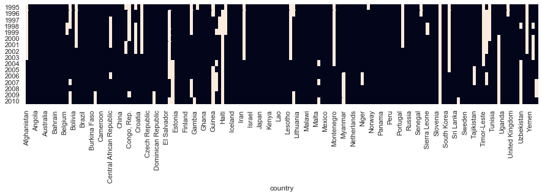

```python
# Military missing data per country / year visually
plt.figure(figsize=(15,3))
sns.heatmap(military_t1.isnull(),yticklabels=True,cbar=False)
```

> I see that there are some countries that have nearly no data, I need to clean then. I fix a threshold of data at values unless for 13 years out of 16 and remove the countries that has no values for more than 3 years. I generate a new dataframe without those countries

```python
# Removing countries with more than 3 years of missing data
military_t1clean=military_t1.dropna(axis=1, how='any', thresh=13, subset=None, inplace=False)
```

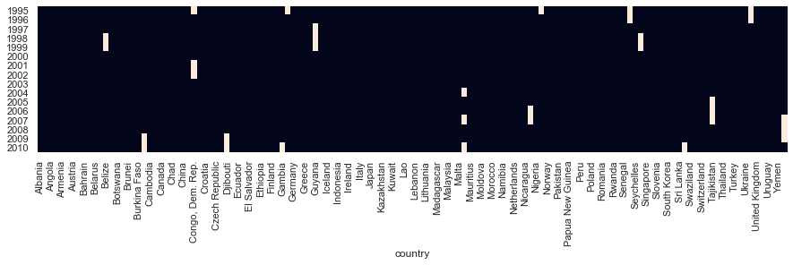

```python
# Military missing data per country / year visually after removing of countries with more than 3 years missing data
plt.figure(figsize=(15,3))
sns.heatmap(military_t1clean.isnull(),yticklabels=True,cbar=False)
```

```python
# I check again the data quality
file_info(military_t1clean, "Military Expend")
```

```
Military Expend : countries:  16 , years:  136 , amount of data: 2176
Nan:  33 ,
1.52 %
```

> There are still 1.52% of missing data. Then I decide to interpolate the values for those countries to get 0 missing data

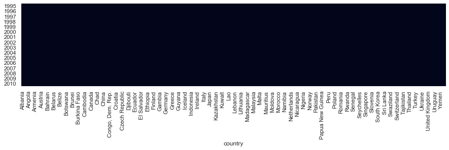

```python
# data missing interpolation, linear and in both directions
military_f_t=military_t1clean.interpolate(method='linear', limit_direction='both', axis=0)
plt.figure(figsize=(15,3))
sns.heatmap(military_f_t.isnull(),yticklabels=True,cbar=False)
```

> I will modify the different data frame to keep the same countries than in military dataframe and at same time I will investigate if there are still missing data

```python
# Transpose military file with final countries
military_f=military_f_t.T
```

```python
#Aling countries on GdP via mergin, then split using name of columns, and finaly rename the columns
merg= military_f.merge(gdp1, on=['country'], how='inner')  #merge both files
gdp_f=merg.loc[:, "1995_y": "2010_y"]                   # new gdp file with contries aligned
gdp_f.rename(columns={'1995_y':'1995','1996_y':'1996','1997_y':'1997',
                        '1998_y':'1998','1999_y':'1999', '2000_y':'2000',
                        '2001_y':'2001','2002_y':'2002','2003_y':'2003',
                        '2004_y':'2004', '2005_y':'2005','2006_y':'2006',
                        '2007_y':'2007','2008_y':'2008','2009_y':'2009','2010_y':'2010' },
                 inplace=True)                            # renaming of columns on gdp
```

> I repeat the operation with all the files

```python
#Aling countries on Health via mergin, then split using name of columns, and finaly rename the columns
merg= military_f.merge(health1, on=['country'], how='inner')
health_f=merg.loc[:, "1995_y": "2010_y"]
health_f.rename(columns={'1995_y':'1995','1996_y':'1996','1997_y':'1997',
                        '1998_y':'1998','1999_y':'1999', '2000_y':'2000',
                        '2001_y':'2001','2002_y':'2002','2003_y':'2003',
                        '2004_y':'2004', '2005_y':'2005','2006_y':'2006',
                        '2007_y':'2007','2008_y':'2008','2009_y':'2009','2010_y':'2010' },
                 inplace=True)

#Aling countries on Democracy via mergin, then split using name of columns, and finaly rename the columns
merg= military_f.merge(democracy1, on=['country'], how='inner')
democracy_f=merg.loc[:, "1995_y": "2010_y"]
democracy_f.rename(columns={'1995_y':'1995','1996_y':'1996','1997_y':'1997',
                        '1998_y':'1998','1999_y':'1999', '2000_y':'2000',
                        '2001_y':'2001','2002_y':'2002','2003_y':'2003',
                        '2004_y':'2004', '2005_y':'2005','2006_y':'2006',
                        '2007_y':'2007','2008_y':'2008','2009_y':'2009','2010_y':'2010' },
                 inplace=True)

#Aling countries on Sugar via mergin, then split using name of columns, and finaly rename the columns
merg= military_f.merge(sugar1, on=['country'], how='inner')
sugar_f=merg.loc[:, "1995_y": "2010_y"]
sugar_f.rename(columns={'1995_y':'1995','1996_y':'1996','1997_y':'1997',
                        '1998_y':'1998','1999_y':'1999', '2000_y':'2000',
                        '2001_y':'2001','2002_y':'2002','2003_y':'2003',
                        '2004_y':'2004', '2005_y':'2005','2006_y':'2006',
                        '2007_y':'2007','2008_y':'2008','2009_y':'2009','2010_y':'2010' },
                 inplace=True)

#Aling countries on Suicide via mergin, then split using name of columns, and finaly rename the columns
merg= military_f.merge(suicide1, on=['country'], how='inner')
suicide_f=merg.loc[:, "1995_y": "2010_y"]
suicide_f.rename(columns={'1995_y':'1995','1996_y':'1996','1997_y':'1997',
                        '1998_y':'1998','1999_y':'1999', '2000_y':'2000',
                        '2001_y':'2001','2002_y':'2002','2003_y':'2003',
                        '2004_y':'2004', '2005_y':'2005','2006_y':'2006',
                        '2007_y':'2007','2008_y':'2008','2009_y':'2009','2010_y':'2010' },
                 inplace=True)
```

> I check the information of those files

```python
print (file_info(gdp_f, "GDP"))
print (file_info(democracy_f, "Democracy"))
print (file_info(military_f, "Military"))
print (file_info(health_f, "Health"))
print (file_info(sugar_f, "Sugar"))
print (file_info(suicide_f, "Suicide"))
```

```
GDP : countries:  136 , years:  16 , amount of data: 2176
Nan:  0 ,
0.0 %

None
Democracy : countries:  130 , years:  16 , amount of data: 2080
Nan:  0 ,
0.0 %

None
Military : countries:  136 , years:  16 , amount of data: 2176
Nan:  0 ,
0.0 %

None
Health : countries:  136 , years:  16 , amount of data: 2176
Nan:  11 ,
0.51 %

None
Sugar : countries:  129 , years:  16 , amount of data: 2064
Nan:  21 ,
1.02 %

None
Suicide : countries:  136 , years:  16 , amount of data: 2176
Nan:  0 ,
0.0 %

None
```

> There are still some missing data on Health and Sugar. I will visually investigate where and when those data are missing

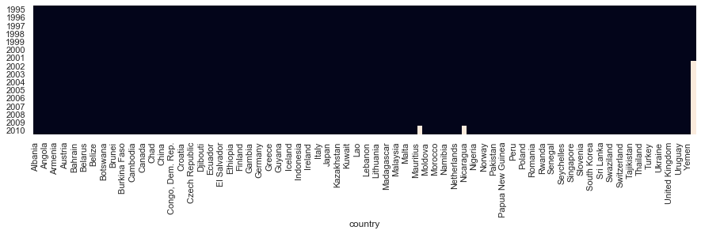

```python
#Health: transpose the file and plot to see where the missing data are
health_ft=health_f.T
plt.figure(figsize=(15,3))
sns.heatmap(health_ft.isnull(),yticklabels=True,cbar=False)
```

> The missing values are concentrated in 3 countries but mainly Yemen. I will keep Yemen in the investigation and I interpolate the data

```python
#Interpolate health values
health_ft=health_ft.interpolate(method='linear', limit_direction='both', axis=0)
```

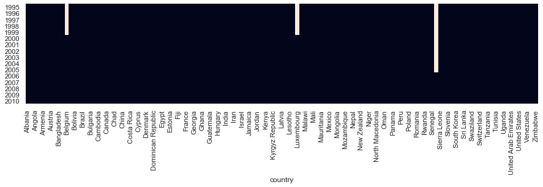

```python
#Sugar: transpose the file and plot to see where the missing data are
sugar_ft=sugar_f.T
plt.figure(figsize=(15,3))
sns.heatmap(sugar_ft.isnull(),yticklabels=True,cbar=False)
```

> The missing values are concentrated in 3 countries but mainly Sierra Leona. I will keep this country in the investigation and I interpolate the data

```python
#Interpolate sugar values
sugar_ft=sugar_ft.interpolate(method='linear', limit_direction='both', axis=0)
```

```python
# Information of each file
print (file_info(gdp_f, "GDP"))
print (file_info(democracy_f, "Democracy"))
print (file_info(military_f, "Military"))
print (file_info(health_f, "Health"))
print (file_info(sugar_f, "Sugar"))
print (file_info(suicide_f, "Suicide"))
```

```
GDP : countries:  136 , years:  16 , amount of data: 2176
Nan:  0 ,
0.0 %

None
Democracy : countries:  130 , years:  16 , amount of data: 2080
Nan:  0 ,
0.0 %

None
Military : countries:  136 , years:  16 , amount of data: 2176
Nan:  0 ,
0.0 %

None
Health : countries:  136 , years:  16 , amount of data: 2176
Nan:  11 ,
0.51 %

None
Sugar : countries:  129 , years:  16 , amount of data: 2064
Nan:  21 ,
1.02 %

None
Suicide : countries:  136 , years:  16 , amount of data: 2176
Nan:  0 ,
0.0 %

None
```

## Exploratory Data Analysis

> I will realize some exporation on the data that I will use later for answering the two questions I will transpose all the data frame, I will calculate the mean of each, I will standardize them to compare per year and by country and I will calculate the increase per year and per country for each dataframe

```python
# Dataframe transpose
gdp_f_t=gdp_f.T
military_f_t=military_f.T
health_f_t=health_f.T
democracy_f_t=democracy_f.T
sugar_f_t=sugar_f.T
suicide_f_t=suicide_f.T
```

```python
# Standardize all dataframe
# Standardize function definition
def standardize(df):
    return (df-df.mean())/df.std(ddof=0)

# Standardize dataframe
gdp_f_std=standardize(gdp_f)
military_f_std=standardize(military_f)
health_f_std=standardize(health_f)
democracy_f_std=standardize(democracy_f)
sugar_f_std=standardize(sugar_f)
suicide_f_std=standardize(suicide_f)

gdp_f_t_std=standardize(gdp_f_t)
military_f_t_std=standardize(military_f_t)
health_f_t_std=standardize(health_f_t)
democracy_f_t_std=standardize(democracy_f_t)
sugar_f_t_std=standardize(sugar_f_t)
suicide_f_t_std=standardize(suicide_f_t)
```

```python
# Increase along the year / countries: Percentage change between the current and a prior element
gdp_f_inc=gdp_f.pct_change(periods=1, fill_method='pad', limit=None, freq=None )
military_f_inc=military_f.pct_change(periods=1, fill_method='pad', limit=None, freq=None )
health_f_inc=health_f.pct_change(periods=1, fill_method='pad', limit=None, freq=None )
democracy_f_inc=democracy_f.pct_change(periods=1, fill_method='pad', limit=None, freq=None )
sugar_f_inc=sugar_f.pct_change(periods=1, fill_method='pad', limit=None, freq=None )
suicide_f_inc=suicide_f.pct_change(periods=1, fill_method='pad', limit=None, freq=None )

gdp_f_t_inc=gdp_f_t.pct_change(periods=1, fill_method='pad', limit=None, freq=None )
military_f_t_inc=military_f_t.pct_change(periods=1, fill_method='pad', limit=None, freq=None )
health_f_t_inc=health_f_t.pct_change(periods=1, fill_method='pad', limit=None, freq=None )
democracy_f_t_inc=democracy_f_t.pct_change(periods=1, fill_method='pad', limit=None, freq=None )
sugar_f_t_inc=sugar_f_t.pct_change(periods=1, fill_method='pad', limit=None, freq=None )
suicide_f_t_inc=suicide_f_t.pct_change(periods=1, fill_method='pad', limit=None, freq=None )
```

> First, let see the evolution of the mean along the time. There is a postive evolution in all indicators, incluiding suicide that decrease along the time.

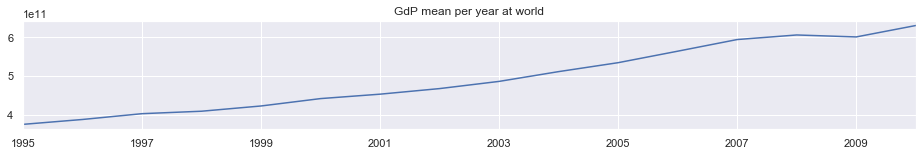

```python
#GdP mean evolution
plt.figure(figsize=(16,2))
plt.title('GdP mean per year at world')
gdp_f.mean().plot(kind='line')
```

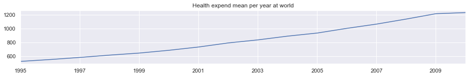

```python
#Health expend  mean evolution
plt.figure(figsize=(16,2))

plt.title('Health expend mean per year at world')
health_f.mean().plot(kind='line')
```

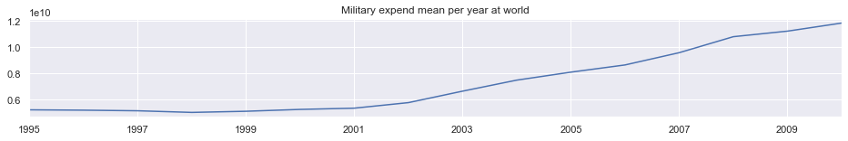

```python
#Military expend mean evolution
plt.figure(figsize=(16,2))

plt.title('Military expend mean per year at world')
military_f.mean().plot(kind='line')
```

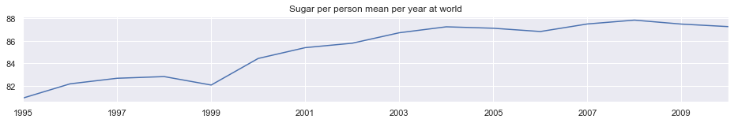

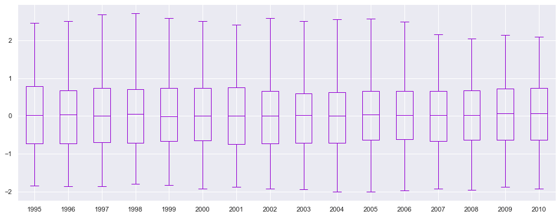

```python
#Sugar per person mean evolution
plt.figure(figsize=(16,2))

plt.title('Sugar per person mean per year at world')
sugar_f.mean().plot(kind='line')



sugar_f_std.plot(figsize=(16,6), kind='box', color='darkviolet')
```

> The boxplot for sugar per person show that the increase along the time has reduce the deviation related to the highest consumer. It means more suger per person in more countries, but still some countries were different tendency. We will come back to contry analsis to asnwer the first question

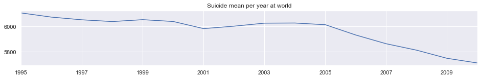

```python
#Suicide mean evolution
plt.figure(figsize=(16,2))

plt.title('Suicide mean per year at world')
suicide_f.mean().plot(kind='line')
```

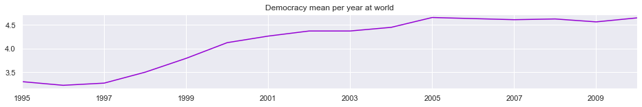

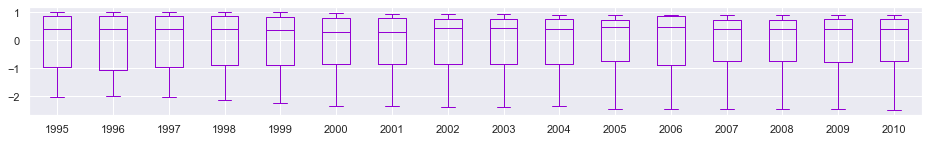

```python
#Democracy mean evolution
plt.figure(figsize=(16,2))

plt.title('Democracy mean per year at world')
democracy_f.mean().plot(kind='line', color='darkviolet')

democracy_f_std.plot(figsize=(16,2), kind='box', color='darkviolet')
```

> The boxplot for democracy show us that there are mayority of the countries move to the democracy but the ones that are in the negative area are farther. It means less non democratic countries but less democracy in the non democratic countries We will come back to contry analsis to asnwer the second questions

```python
## Funtions for standardize:
# Standardize each column of the given DataFrame

def standardize(df):
    return (df-df.mean())/df.std(ddof=0)

# Standardize each row of the given DataFrame
def standardize_rows(df):
    mean_diffs=df.sub(df.mean(axis='columns'), axis='index')
    return mean_diffs.div(df.std(ddof=0, axis='columns'), axis='index')
```

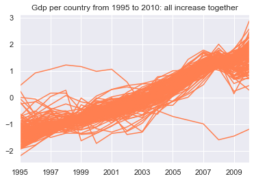

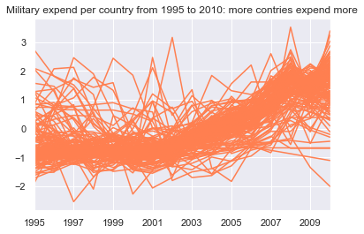

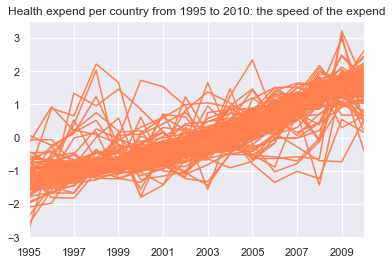

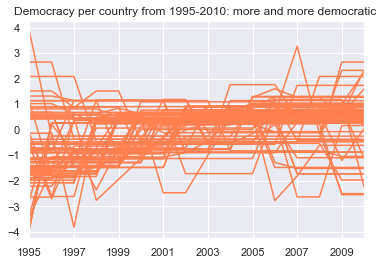

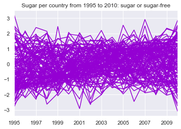

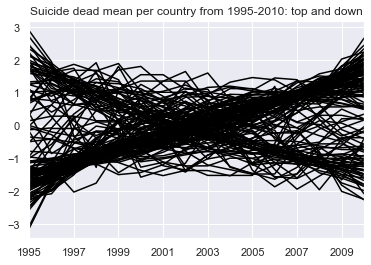

```python
# Chart on standard evolution along the time, all countries

gdp_f_t_std=standardize(gdp_f_t).plot(kind='line', color='coral',legend=False)
plt.title('Gdp per country from 1995 to 2010: all increase together')

military_f_t_std=standardize(military_f_t).plot(kind='line', color='coral',legend=False)
plt.title('Military expend per country from 1995 to 2010: more contries expend more')

health_f_t_std=standardize(health_f_t).plot(kind='line', color='coral',legend=False)
plt.title('Health expend per country from 1995 to 2010: the speed of the expend')

democracy_f_t_std=standardize(democracy_f_t).plot(kind='line', color='coral',legend=False)
plt.title('Democracy per country from 1995-2010: more and more democratic ')

sugar_f_t_std=standardize(sugar_f_t).plot(kind='line', color='darkviolet',legend=False)
plt.title('Sugar per country from 1995 to 2010: sugar or sugar-free')

standardize(suicide_f_t).plot(kind='line', color='black',legend=False)
plt.title('Suicide dead mean per country from 1995-2010: top and down')
print (end)
```

### Research Question 1 ( Have GbP along the period influence the expend in military and health, suicide level and sugar consuption? General world view and focus on countries with higher positive or negative correlation (over 0.8 and below -0.8))

#### Q1.1. Correlation between GdP and military expend

```python
# Funtion to calculate the percentaje and amounf of countries over a threshold
def percentaje (serie, up_threshold_0_xx, down_threshold_0_xx, what ):
    a=list()
    for i in serie:
        if i>up_threshold_0_xx:
            a.append(i)
    print ("The correlation over ", up_threshold_0_xx, "is:",(round((len(a))/len(serie)*100)),"%")
    print('Number of ',what, ' over ', up_threshold_0_xx, "is:",len(a))

    b=list()
    for i in serie:
        if i<down_threshold_0_xx:
            b.append(i)
    print ("The correlation below ", down_threshold_0_xx, "is:", (round((len(b))/len(serie)*100)),"%")
    print('Number of countries below  ', down_threshold_0_xx, "is:", len(b))
```

```
GdP vs Military expend yearly correlation details:
The correlation over  0.8 is: 100 %
Number of  years  over  0.8 is: 16
The correlation below  0.2 is: 0 %
Number of countries below   0.2 is: 0
```

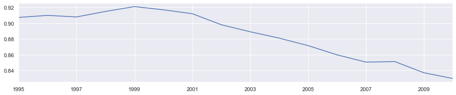

```python
# # GdP vs Military expend time evolution correlation view
print( 'GdP vs Military expend yearly correlation details:')
plt.figure(figsize=(16,3))
percentaje ((gdp_f.corrwith(military_f, axis=0, method="pearson")),0.8, 0.2,  'years')
(gdp_f.corrwith(military_f, axis=0, method="pearson")).plot(kind='line')
```

```python
# GdP vs Military expend contry correlation view:
print( 'GdP vs Military expend correlation country view:')
#plt.figure(figsize=(16,4))
percentaje ((gdp_f.corrwith(military_f, axis=1, method="pearson")), 0.8, -0.8, 'countries')
#(gdp_f.corrwith(military_f, axis=1, method="pearson")).plot(kind='bar')
```

```
GdP vs Military expend correlation country view:
The correlation over  0.8 is: 62 %
Number of  countries  over  0.8 is: 84
The correlation below  -0.8 is: 0 %
Number of countries below   -0.8 is: 0
```

```python
## Function to count and show the column:
# Print the title of the columns from a given DataFrame and
# print the title of the columns and the title of rows from a given DataFrame
# argument is file name

def column (df):
    for i in df.columns:
        print(i,end=", ")

def index (df):
    for i in df.index:
        print(i,end=", ")

def column_index (df):
    for i in df.columns:
        print(i,end=", ")
    print ("")
    for i in df.index:
        print(i,end=", ")
```

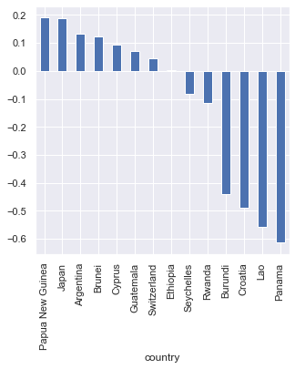

```python
# Chart of countries with lower correlation and negative correlation
plt.figure(figsize=(5,5))
(gdp_f.corrwith(military_f, axis=1, method="pearson")).sort_values(ascending=False,
                na_position="first")[-14:].plot(kind='bar')
```

> We could consider that the variation on GdP tend to generate a variation on the military expenditure with the same sense (+,+; -,-)

```python
# List of countries with higher and lower correlation
print ("The 10 countries with higher correlation are:")
index((gdp_f.corrwith(military_f, axis=1, method="pearson")).sort_values(na_position="first")[-10:])
print (end)
print ("The 10 countries with correlation index below 0.2 and negative correlation are :")
index ((gdp_f.corrwith(military_f, axis=1, method="pearson")).
                  sort_values(ascending=False, na_position="first")[-10:])
```

```
The 10 countries with higher correlation are:
Nepal, Azerbaijan, China, Czech Republic, Venezuela, Angola, Kenya, Lithuania, India, Bulgaria,

The 10 countries with correlation index below 0.2 and negative correlation are :
Cyprus, Guatemala, Switzerland, Ethiopia, Seychelles, Rwanda, Burundi, Croatia, Lao, Panama,
```

#### Q1.2. Correlation between GdP and health

```
GdP vs Health expend yearly correlation details:
The correlation over  0.8 is: 88 %
Number of  years  over  0.8 is: 120
The correlation below  0.2 is: 2 %
Number of countries below   0.2 is: 3
```

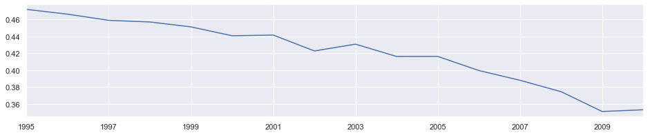

```python
# # GdP vs Health expend time evolution correlation view
print( 'GdP vs Health expend yearly correlation details:')
plt.figure(figsize=(16,3))
percentaje ((gdp_f_t.corrwith(health_f_t, axis=0, method="pearson")),0.8, 0.2,  'years')
(gdp_f_t.corrwith(health_f_t, axis=1, method="pearson")).plot(kind='line')
```

```python
# GdP vs Health expend contriey correlation view:
print( 'GdP vs health expend correlation country view:')
#plt.figure(figsize=(16,4))
percentaje ((gdp_f.corrwith(health_f, axis=1, method="pearson")), 0.8, -0.8, 'countries')
#(gdp_f.corrwith(health_f, axis=1, method="pearson")).plot(kind='bar')
```

```
GdP vs health expend correlation country view:
The correlation over  0.8 is: 88 %
Number of  countries  over  0.8 is: 120
The correlation below  -0.8 is: 0 %
Number of countries below   -0.8 is: 0
```

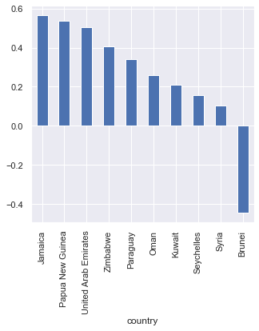

```python
# Chart of countries with lower correlation and negative correlation
plt.figure(figsize=(5,5))
(gdp_f.corrwith(health_f, axis=1, method="pearson")).sort_values(ascending=False,
                na_position="first")[-10:].plot(kind='bar')
```

> We observe that for more than 88% of the countries the correlation is positive and over 0.8 We can see that there are no countries with high negative correlation

```python
# List of countries with higher and lower correlation
print ("The 10 countries with higher correlation are:")
index((gdp_f.corrwith(health_f, axis=1, method="pearson")).sort_values(na_position="first")[-10:])
print (end)
print ("The 10 countries with lower correlation are:")
index ((gdp_f.corrwith(health_f, axis=1, method="pearson")).
                     sort_values(ascending=False, na_position="first")[-10:])
```

```
The 10 countries with higher correlation are:
Senegal, Tunisia, Burkina Faso, Cyprus, Brazil, South Africa, Belarus, Albania, Australia, India,

The 10 countries with lower correlation are:
Jamaica, Papua New Guinea, United Arab Emirates, Zimbabwe, Paraguay, Oman, Kuwait, Seychelles, Syria, Brunei,
```

#### Q1.3. Correlation between GdP and sugar per person

```
GdP vs sugar per person yearly correlation details:
The correlation over  0.8 is: 0 %
Number of  years  over  0.8 is: 0
The correlation below  0.2 is: 50 %
Number of countries below   0.2 is: 8
```

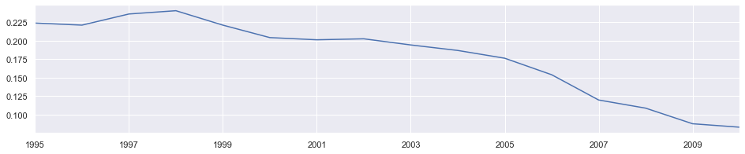

```python
# # GdP vs sugar per person time evolution correlation view
print( 'GdP vs sugar per person yearly correlation details:')
plt.figure(figsize=(16,3))
percentaje ((gdp_f.corrwith(sugar_f, axis=0, method="pearson")),0.8, 0.2,  'years')
(gdp_f.corrwith(sugar_f, axis=0, method="pearson")).plot(kind='line')
```

```python
# GdP vs sugar per person country correlation view:
print( 'GdP vs sugar expend correlation country view:')
percentaje ((gdp_f.corrwith(sugar_f, axis=1, method="pearson")), 0.8, -0.8, 'countries')
```

```
GdP vs sugar expend correlation country view:
The correlation over  0.8 is: 21 %
Number of  countries  over  0.8 is: 29
The correlation below  -0.8 is: 7 %
Number of countries below   -0.8 is: 10
```

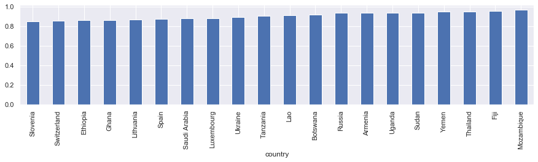

```python
# Chart of countries with high positive correlation
plt.figure(figsize=(15,3))
(gdp_f.corrwith(sugar_f, axis=1, method="pearson")). sort_values(na_position="first")[-20:].plot(kind='bar')
```

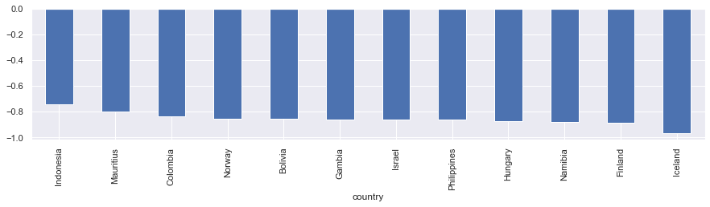

```python
# Chart of countries with high negative correlation
plt.figure(figsize=(15,3))
(gdp_f.corrwith(sugar_f, axis=1, method="pearson")).sort_values(ascending=False,
                na_position="first")[-12:].plot(kind='bar')
```

> We observe that only in 21% of the countries the correlation is positive and over 0.8 Regarding negative correlation, we see only 7% of the countries with hihg negative correlation

> We could not say that Gdp and sugar has a direct correlation, in any case for some countries there is a strong positive correlation and for others storng negative.

> As seen before in the boxplot, sugar consuption increase along the time and for mayority of the countries. But there are countries that consume over and below the mean with nearly 2 point deviation

```python
# List of countries with higher and lower correlation
print ("The 30 countries with higher correlation between gdp and sugar are:")
gdp_sugar_hc=index((gdp_f.corrwith(sugar_f, axis=1, method="pearson")).
                   sort_values(na_position="first")[-29:])
print(gdp_sugar_hc)
print ("The 15 countries with lower correlation between gdp and sugar are:")
gdp_sugar_lc=index ((gdp_f.corrwith(sugar_f, axis=1, method="pearson")).
                    sort_values(ascending=False, na_position="first")[-10:])
print(gdp_sugar_lc)
```

[output not shown]

#### Q1.4. Correlation between GdP and suicide

```
GdP vs suicide expend yearly correlation details:
The correlation over  0.8 is: 0 %
Number of  years  over  0.8 is: 0
The correlation below  -0.8 is: 0 %
Number of countries below   -0.8 is: 0
```

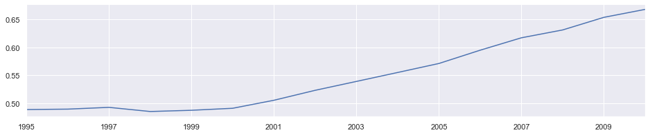

```python
# # GdP vs suicide dead time evolution correlation view
print( 'GdP vs suicide expend yearly correlation details:')
plt.figure(figsize=(16,3))
percentaje ((gdp_f.corrwith(suicide_f, axis=0, method="pearson")),0.8, -0.8,  'years')
(gdp_f.corrwith(suicide_f, axis=0, method="pearson")).plot(kind='line')
```

```python
# GdP vs suicide contry correlation view
print( 'GdP vs suicide expend correlation country view:')
#plt.figure(figsize=(16,2))
percentaje ((gdp_f.corrwith(suicide_f, axis=1, method="pearson")), 0.8, -0.8, 'countries')
#(gdp_f.corrwith(suicide_f, axis=1, method="pearson")).plot(kind='bar')
```

```
GdP vs suicide expend correlation country view:
The correlation over  0.8 is: 49 %
Number of  countries  over  0.8 is: 66
The correlation below  -0.8 is: 22 %
Number of countries below   -0.8 is: 30
```

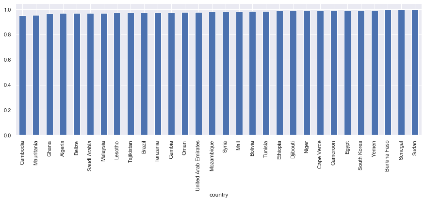

```python
# Chart of countries with high postive correlation
plt.figure(figsize=(15,5))
(gdp_f.corrwith(suicide_f, axis=1, method="pearson")). sort_values(na_position="first")[-30:].plot(kind='bar')
```

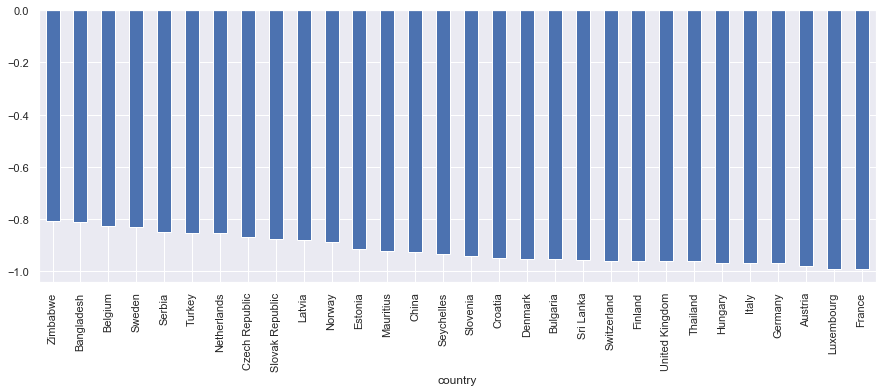

```python
# Chart of countries with high negative correlation
plt.figure(figsize=(15,5))
(gdp_f.corrwith(suicide_f, axis=1, method="pearson")).sort_values(ascending=False,
                na_position="first")[-30:].plot(kind='bar')
```

> We observe that the correlation is positive and over 0.8 for 49% of the countries Regarding negative correlation, we see that 22% of the countries has a hihg negative correlation

> We could not say that Gdp and suicide has a direct correlation, in any case for some countries there is a strong positive correlation and for others storng negative.

```python
print ("The 30 countries with higher positive correlation between gdp and suicide are:")
gdp_suicide_hc=index((gdp_f.corrwith(suicide_f, axis=1, method="pearson")).
                   sort_values(na_position="first")[-30:])
print(gdp_suicide_hc)

print ("The 30 countries with higher negative correlation between gdp and suicide are:")
gdp_suicide_lc=index ((gdp_f.corrwith(suicide_f, axis=1, method="pearson")).
                    sort_values(ascending=False, na_position="first")[-30:])
```

[output not shown]